# Trabajo Final Diplomatura EDN

## Tabla de contenido:

- **Data set original y descripción**: Explicación de las variables, objetivo del trabajo y análisis del caso a estudiar
- **Análisis exploratorio de datos**
- **Modelo de clasificación**: Implementación de los modelos de clasificación y métricas.
- **Conclusión**

Fecha: *Octubre 2021*

### Data set

Se ha utilizado el siguiente dataset: https://www.kaggle.com/andrewmvd/fetal-health-classification

## Descripción del data set

El data set contiene información sobre distintos parámetros que se obtienen al realizar un estudio llamado tococardiograma fetal (CTG) en embarazadas durante su trabajo de parto. Este estudio es de bajo costo y permite detectar posibles riesgos en el feto en el momento del trabajo de parto, por lo tanto poder interpretar los resutados de los mismos colabora en la toma de decisiones a la hora del parto.

Se describen 21 atributos utilizados en la medición de la frecuencia cardíaca fetal (FHR) y las contracciones uterinas (UC) en los CTG. Los datos provienen de 2126 mujeres embarazadas que estaban en el tercer trimestre de embarazo de Portugal. De acuerdo a estándares establecidos, las variables de riesgo utilizadas para analizar el estado del feto incluyen descripciones cuantitativas de FHR y UC.

Las CTG de las gestantes fueron clasificadas por tres expertos especialistas en obstetricia, estableciendo cuáles eran consideradas como **1- normales, 2- sospechosos y 3- patológicos**.

Las variables del data set son las siguientes:

**Baseline value**: frecuancia cardíaca fetal en latidos por minutos.

**Accelerations**: número de aceleraciones por segundo.

**Fetal_movement**: número de movimientos fetales por segundo.

**Uterine_contractions**: número de contracciones uterinas por segundo.

**Light_decelerations**: número de desaceleraciones de luz por segundo.

**Severe_decelerations**: número de desaceleraciones severas por segundo.

**Prolongued_decelerations**: número de desaceleraciones prolongadas por segundo.

**Abnormal_short_term_varability**:porcentaje de tiempo con variabilidad anormal.

**Mean_value_of_short_term_variability**: Promedio de variabilidad de corto plazo.

**Percentage_of_time_with_abnormal_long_term_variability**:Porcentaje de tiempo con variabilidad anormal de largo plazo.

**Mean_value_of_long_term_variability**:Valor promedio de variabilidad a largo plazo.

**Histogram_width**: Ancho del histograma de FHR.

**Histogram_min**:Mínimo del histograma de FHR.

**Histogram_max**: Máximo del histograma de FHR.

**Histogram_number_of_peaks**: Número de picos del histograma.

**Histogram_number_of_zeroes**: Número de ceros del histograma.

**Histogram_mode**: Moda del histograma.

**Histogram_mean**:Media del histograma.

**Histogram_median**: Mediana del histograma.

**Histogram_variance**: Variancia del histograma.

**Histogram_tendency**: Tendencia del histograma.

**Fetal_health**: Clase según el estado fetal.

El **objetivo** de este trabajo es emplear el el data set para desarrollar un modelo de aprendizaje automático que pueda clasificar fetos de alto riesgo (tanto sospechosos como patológicos) con tanta precisión como profesionales médicos altamente capacitados.

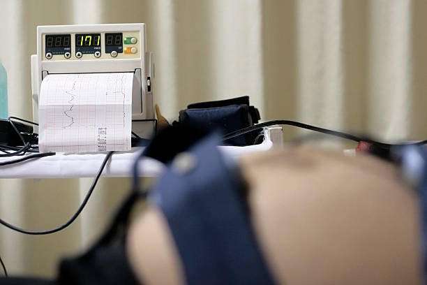

```python
# importación de librerías
import pandas as pd
import numpy as np
import seaborn as sns
import matplotlib.pyplot as plt
from sklearn.ensemble import RandomForestClassifier
from sklearn.model_selection import StratifiedKFold
from sklearn.model_selection import cross_val_score
```

```python
!pip install missingno
```

```python
#Carga de datos
ds = pd.read_csv('C:/Users/Marina/Desktop/Diplomatura DS/TrabajoFinal/fetal_health.csv')
```

## Análisis exploratorio de datos

Se realizará un análisis exploratorio de datos, comenzando por visualizar los datos, analizar el número de variables y de registros totales, y luego los estadísticos descriptivos de las variables:

```python
#Observo primeros 10 registros
ds.head(10)
```

|  | baseline value | accelerations | fetal_movement | uterine_contractions | light_decelerations | severe_decelerations | prolongued_decelerations | abnormal_short_term_variability | mean_value_of_short_term_variability | percentage_of_time_with_abnormal_long_term_variability | ... | histogram_min | histogram_max | histogram_number_of_peaks | histogram_number_of_zeroes | histogram_mode | histogram_mean | histogram_median | histogram_variance | histogram_tendency | fetal_health |
| --- | --- | --- | --- | --- | --- | --- | --- | --- | --- | --- | --- | --- | --- | --- | --- | --- | --- | --- | --- | --- | --- |
| 0 | 120.0 | 0.000 | 0.0 | 0.000 | 0.000 | 0.0 | 0.000 | 73.0 | 0.5 | 43.0 | ... | 62.0 | 126.0 | 2.0 | 0.0 | 120.0 | 137.0 | 121.0 | 73.0 | 1.0 | 2.0 |
| 1 | 132.0 | 0.006 | 0.0 | 0.006 | 0.003 | 0.0 | 0.000 | 17.0 | 2.1 | 0.0 | ... | 68.0 | 198.0 | 6.0 | 1.0 | 141.0 | 136.0 | 140.0 | 12.0 | 0.0 | 1.0 |
| 2 | 133.0 | 0.003 | 0.0 | 0.008 | 0.003 | 0.0 | 0.000 | 16.0 | 2.1 | 0.0 | ... | 68.0 | 198.0 | 5.0 | 1.0 | 141.0 | 135.0 | 138.0 | 13.0 | 0.0 | 1.0 |
| 3 | 134.0 | 0.003 | 0.0 | 0.008 | 0.003 | 0.0 | 0.000 | 16.0 | 2.4 | 0.0 | ... | 53.0 | 170.0 | 11.0 | 0.0 | 137.0 | 134.0 | 137.0 | 13.0 | 1.0 | 1.0 |
| 4 | 132.0 | 0.007 | 0.0 | 0.008 | 0.000 | 0.0 | 0.000 | 16.0 | 2.4 | 0.0 | ... | 53.0 | 170.0 | 9.0 | 0.0 | 137.0 | 136.0 | 138.0 | 11.0 | 1.0 | 1.0 |
| 5 | 134.0 | 0.001 | 0.0 | 0.010 | 0.009 | 0.0 | 0.002 | 26.0 | 5.9 | 0.0 | ... | 50.0 | 200.0 | 5.0 | 3.0 | 76.0 | 107.0 | 107.0 | 170.0 | 0.0 | 3.0 |
| 6 | 134.0 | 0.001 | 0.0 | 0.013 | 0.008 | 0.0 | 0.003 | 29.0 | 6.3 | 0.0 | ... | 50.0 | 200.0 | 6.0 | 3.0 | 71.0 | 107.0 | 106.0 | 215.0 | 0.0 | 3.0 |
| 7 | 122.0 | 0.000 | 0.0 | 0.000 | 0.000 | 0.0 | 0.000 | 83.0 | 0.5 | 6.0 | ... | 62.0 | 130.0 | 0.0 | 0.0 | 122.0 | 122.0 | 123.0 | 3.0 | 1.0 | 3.0 |
| 8 | 122.0 | 0.000 | 0.0 | 0.002 | 0.000 | 0.0 | 0.000 | 84.0 | 0.5 | 5.0 | ... | 62.0 | 130.0 | 0.0 | 0.0 | 122.0 | 122.0 | 123.0 | 3.0 | 1.0 | 3.0 |
| 9 | 122.0 | 0.000 | 0.0 | 0.003 | 0.000 | 0.0 | 0.000 | 86.0 | 0.3 | 6.0 | ... | 62.0 | 130.0 | 1.0 | 0.0 | 122.0 | 122.0 | 123.0 | 1.0 | 1.0 | 3.0 |

10 rows × 22 columns

```python
#Observo útimos 3 registros
ds.tail(3)
```

|  | baseline value | accelerations | fetal_movement | uterine_contractions | light_decelerations | severe_decelerations | prolongued_decelerations | abnormal_short_term_variability | mean_value_of_short_term_variability | percentage_of_time_with_abnormal_long_term_variability | ... | histogram_min | histogram_max | histogram_number_of_peaks | histogram_number_of_zeroes | histogram_mode | histogram_mean | histogram_median | histogram_variance | histogram_tendency | fetal_health |
| --- | --- | --- | --- | --- | --- | --- | --- | --- | --- | --- | --- | --- | --- | --- | --- | --- | --- | --- | --- | --- | --- |
| 2123 | 140.0 | 0.001 | 0.000 | 0.007 | 0.0 | 0.0 | 0.0 | 79.0 | 0.4 | 20.0 | ... | 103.0 | 170.0 | 5.0 | 0.0 | 153.0 | 148.0 | 152.0 | 4.0 | 1.0 | 2.0 |
| 2124 | 140.0 | 0.001 | 0.000 | 0.006 | 0.0 | 0.0 | 0.0 | 78.0 | 0.4 | 27.0 | ... | 103.0 | 169.0 | 6.0 | 0.0 | 152.0 | 147.0 | 151.0 | 4.0 | 1.0 | 2.0 |
| 2125 | 142.0 | 0.002 | 0.002 | 0.008 | 0.0 | 0.0 | 0.0 | 74.0 | 0.4 | 36.0 | ... | 117.0 | 159.0 | 2.0 | 1.0 | 145.0 | 143.0 | 145.0 | 1.0 | 0.0 | 1.0 |

3 rows × 22 columns

```python
ds.info()
```

```
<class 'pandas.core.frame.DataFrame'>
RangeIndex: 2126 entries, 0 to 2125
Data columns (total 22 columns):
 #   Column                                                  Non-Null Count  Dtype
---  ------                                                  --------------  -----
 0   baseline value                                          2126 non-null   float64
 1   accelerations                                           2126 non-null   float64
 2   fetal_movement                                          2126 non-null   float64
 3   uterine_contractions                                    2126 non-null   float64
 4   light_decelerations                                     2126 non-null   float64
 5   severe_decelerations                                    2126 non-null   float64
 6   prolongued_decelerations                                2126 non-null   float64
 7   abnormal_short_term_variability                         2126 non-null   float64
 8   mean_value_of_short_term_variability                    2126 non-null   float64
 9   percentage_of_time_with_abnormal_long_term_variability  2126 non-null   float64
 10  mean_value_of_long_term_variability                     2126 non-null   float64
 11  histogram_width                                         2126 non-null   float64
 12  histogram_min                                           2126 non-null   float64
 13  histogram_max                                           2126 non-null   float64
 14  histogram_number_of_peaks                               2126 non-null   float64
 15  histogram_number_of_zeroes                              2126 non-null   float64
 16  histogram_mode                                          2126 non-null   float64
 17  histogram_mean                                          2126 non-null   float64
 18  histogram_median                                        2126 non-null   float64
 19  histogram_variance                                      2126 non-null   float64
 20  histogram_tendency                                      2126 non-null   float64
 21  fetal_health                                            2126 non-null   float64
dtypes: float64(22)
memory usage: 365.5 KB
```

```python
#Observación rápida de los datos y estadísticos descriptivos
ds.describe()
```

|  | baseline value | accelerations | fetal_movement | uterine_contractions | light_decelerations | severe_decelerations | prolongued_decelerations | abnormal_short_term_variability | mean_value_of_short_term_variability | percentage_of_time_with_abnormal_long_term_variability | ... | histogram_min | histogram_max | histogram_number_of_peaks | histogram_number_of_zeroes | histogram_mode | histogram_mean | histogram_median | histogram_variance | histogram_tendency | fetal_health |
| --- | --- | --- | --- | --- | --- | --- | --- | --- | --- | --- | --- | --- | --- | --- | --- | --- | --- | --- | --- | --- | --- |
| count | 2126.000000 | 2126.000000 | 2126.000000 | 2126.000000 | 2126.000000 | 2126.000000 | 2126.000000 | 2126.000000 | 2126.000000 | 2126.00000 | ... | 2126.000000 | 2126.000000 | 2126.000000 | 2126.000000 | 2126.000000 | 2126.000000 | 2126.000000 | 2126.000000 | 2126.000000 | 2126.000000 |
| mean | 133.303857 | 0.003178 | 0.009481 | 0.004366 | 0.001889 | 0.000003 | 0.000159 | 46.990122 | 1.332785 | 9.84666 | ... | 93.579492 | 164.025400 | 4.068203 | 0.323612 | 137.452023 | 134.610536 | 138.090310 | 18.808090 | 0.320320 | 1.304327 |
| std | 9.840844 | 0.003866 | 0.046666 | 0.002946 | 0.002960 | 0.000057 | 0.000590 | 17.192814 | 0.883241 | 18.39688 | ... | 29.560212 | 17.944183 | 2.949386 | 0.706059 | 16.381289 | 15.593596 | 14.466589 | 28.977636 | 0.610829 | 0.614377 |
| min | 106.000000 | 0.000000 | 0.000000 | 0.000000 | 0.000000 | 0.000000 | 0.000000 | 12.000000 | 0.200000 | 0.00000 | ... | 50.000000 | 122.000000 | 0.000000 | 0.000000 | 60.000000 | 73.000000 | 77.000000 | 0.000000 | -1.000000 | 1.000000 |
| 25% | 126.000000 | 0.000000 | 0.000000 | 0.002000 | 0.000000 | 0.000000 | 0.000000 | 32.000000 | 0.700000 | 0.00000 | ... | 67.000000 | 152.000000 | 2.000000 | 0.000000 | 129.000000 | 125.000000 | 129.000000 | 2.000000 | 0.000000 | 1.000000 |
| 50% | 133.000000 | 0.002000 | 0.000000 | 0.004000 | 0.000000 | 0.000000 | 0.000000 | 49.000000 | 1.200000 | 0.00000 | ... | 93.000000 | 162.000000 | 3.000000 | 0.000000 | 139.000000 | 136.000000 | 139.000000 | 7.000000 | 0.000000 | 1.000000 |
| 75% | 140.000000 | 0.006000 | 0.003000 | 0.007000 | 0.003000 | 0.000000 | 0.000000 | 61.000000 | 1.700000 | 11.00000 | ... | 120.000000 | 174.000000 | 6.000000 | 0.000000 | 148.000000 | 145.000000 | 148.000000 | 24.000000 | 1.000000 | 1.000000 |
| max | 160.000000 | 0.019000 | 0.481000 | 0.015000 | 0.015000 | 0.001000 | 0.005000 | 87.000000 | 7.000000 | 91.00000 | ... | 159.000000 | 238.000000 | 18.000000 | 10.000000 | 187.000000 | 182.000000 | 186.000000 | 269.000000 | 1.000000 | 3.000000 |

8 rows × 22 columns

El tipo de dato es númerico para todas las variables, el número total de registros es 2126 y el número de variables es 21, como se informó en la descripción inicial.

Realizamos un control para ver si existen datos nulos dentro del set de datos:

```python
# Controlando valores nulos
ds.isnull().sum()
```

```
baseline value                                            0
accelerations                                             0
fetal_movement                                            0
uterine_contractions                                      0
light_decelerations                                       0
severe_decelerations                                      0
prolongued_decelerations                                  0
abnormal_short_term_variability                           0
mean_value_of_short_term_variability                      0
percentage_of_time_with_abnormal_long_term_variability    0
mean_value_of_long_term_variability                       0
histogram_width                                           0
histogram_min                                             0
histogram_max                                             0
histogram_number_of_peaks                                 0
histogram_number_of_zeroes                                0
histogram_mode                                            0
histogram_mean                                            0
histogram_median                                          0
histogram_variance                                        0
histogram_tendency                                        0
fetal_health                                              0
dtype: int64
```

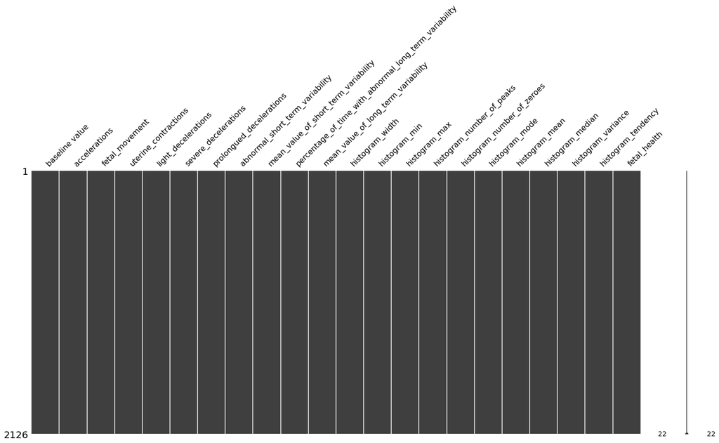

```python
#Visualización de los nulos
import missingno as msno
msno.matrix(ds)
plt.savefig("missing.jpg", bbox_inches='tight')
```

Podemos ver que no existen datos nulos en el set.

Se remueven los datos duplicados:

```python
#Saco datos duplicados con respecto a todas las variables (columnas)
ds_sin_dup = ds.drop_duplicates()
ds_sin_dup
```

|  | baseline value | accelerations | fetal_movement | uterine_contractions | light_decelerations | severe_decelerations | prolongued_decelerations | abnormal_short_term_variability | mean_value_of_short_term_variability | percentage_of_time_with_abnormal_long_term_variability | ... | histogram_min | histogram_max | histogram_number_of_peaks | histogram_number_of_zeroes | histogram_mode | histogram_mean | histogram_median | histogram_variance | histogram_tendency | fetal_health |
| --- | --- | --- | --- | --- | --- | --- | --- | --- | --- | --- | --- | --- | --- | --- | --- | --- | --- | --- | --- | --- | --- |
| 0 | 120.0 | 0.000 | 0.000 | 0.000 | 0.000 | 0.0 | 0.0 | 73.0 | 0.5 | 43.0 | ... | 62.0 | 126.0 | 2.0 | 0.0 | 120.0 | 137.0 | 121.0 | 73.0 | 1.0 | 2.0 |
| 1 | 132.0 | 0.006 | 0.000 | 0.006 | 0.003 | 0.0 | 0.0 | 17.0 | 2.1 | 0.0 | ... | 68.0 | 198.0 | 6.0 | 1.0 | 141.0 | 136.0 | 140.0 | 12.0 | 0.0 | 1.0 |
| 2 | 133.0 | 0.003 | 0.000 | 0.008 | 0.003 | 0.0 | 0.0 | 16.0 | 2.1 | 0.0 | ... | 68.0 | 198.0 | 5.0 | 1.0 | 141.0 | 135.0 | 138.0 | 13.0 | 0.0 | 1.0 |
| 3 | 134.0 | 0.003 | 0.000 | 0.008 | 0.003 | 0.0 | 0.0 | 16.0 | 2.4 | 0.0 | ... | 53.0 | 170.0 | 11.0 | 0.0 | 137.0 | 134.0 | 137.0 | 13.0 | 1.0 | 1.0 |
| 4 | 132.0 | 0.007 | 0.000 | 0.008 | 0.000 | 0.0 | 0.0 | 16.0 | 2.4 | 0.0 | ... | 53.0 | 170.0 | 9.0 | 0.0 | 137.0 | 136.0 | 138.0 | 11.0 | 1.0 | 1.0 |
| ... | ... | ... | ... | ... | ... | ... | ... | ... | ... | ... | ... | ... | ... | ... | ... | ... | ... | ... | ... | ... | ... |
| 2121 | 140.0 | 0.000 | 0.000 | 0.007 | 0.000 | 0.0 | 0.0 | 79.0 | 0.2 | 25.0 | ... | 137.0 | 177.0 | 4.0 | 0.0 | 153.0 | 150.0 | 152.0 | 2.0 | 0.0 | 2.0 |
| 2122 | 140.0 | 0.001 | 0.000 | 0.007 | 0.000 | 0.0 | 0.0 | 78.0 | 0.4 | 22.0 | ... | 103.0 | 169.0 | 6.0 | 0.0 | 152.0 | 148.0 | 151.0 | 3.0 | 1.0 | 2.0 |
| 2123 | 140.0 | 0.001 | 0.000 | 0.007 | 0.000 | 0.0 | 0.0 | 79.0 | 0.4 | 20.0 | ... | 103.0 | 170.0 | 5.0 | 0.0 | 153.0 | 148.0 | 152.0 | 4.0 | 1.0 | 2.0 |
| 2124 | 140.0 | 0.001 | 0.000 | 0.006 | 0.000 | 0.0 | 0.0 | 78.0 | 0.4 | 27.0 | ... | 103.0 | 169.0 | 6.0 | 0.0 | 152.0 | 147.0 | 151.0 | 4.0 | 1.0 | 2.0 |
| 2125 | 142.0 | 0.002 | 0.002 | 0.008 | 0.000 | 0.0 | 0.0 | 74.0 | 0.4 | 36.0 | ... | 117.0 | 159.0 | 2.0 | 1.0 | 145.0 | 143.0 | 145.0 | 1.0 | 0.0 | 1.0 |

2113 rows × 22 columns

```python
ds_sin_dup.info()
```

```
<class 'pandas.core.frame.DataFrame'>
Int64Index: 2113 entries, 0 to 2125
Data columns (total 22 columns):
 #   Column                                                  Non-Null Count  Dtype
---  ------                                                  --------------  -----
 0   baseline value                                          2113 non-null   float64
 1   accelerations                                           2113 non-null   float64
 2   fetal_movement                                          2113 non-null   float64
 3   uterine_contractions                                    2113 non-null   float64
 4   light_decelerations                                     2113 non-null   float64
 5   severe_decelerations                                    2113 non-null   float64
 6   prolongued_decelerations                                2113 non-null   float64
 7   abnormal_short_term_variability                         2113 non-null   float64
 8   mean_value_of_short_term_variability                    2113 non-null   float64
 9   percentage_of_time_with_abnormal_long_term_variability  2113 non-null   float64
 10  mean_value_of_long_term_variability                     2113 non-null   float64
 11  histogram_width                                         2113 non-null   float64
 12  histogram_min                                           2113 non-null   float64
 13  histogram_max                                           2113 non-null   float64
 14  histogram_number_of_peaks                               2113 non-null   float64
 15  histogram_number_of_zeroes                              2113 non-null   float64
 16  histogram_mode                                          2113 non-null   float64
 17  histogram_mean                                          2113 non-null   float64
 18  histogram_median                                        2113 non-null   float64
 19  histogram_variance                                      2113 non-null   float64
 20  histogram_tendency                                      2113 non-null   float64
 21  fetal_health                                            2113 non-null   float64
dtypes: float64(22)
memory usage: 379.7 KB
```

Podemos comprobar que se eliminaron 13 registros y ahora hay 2113 registros únicos en el set.

Se desea analizar la cantidad de registros de cada clase para ver si las mismas se encuentran balanceadas. Para esto se realizará un *gráfico de barras* tradicional que cuenta el total de registros de cada clase:

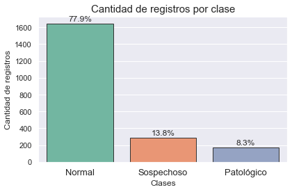

```python
#Gráfico de barras indicando cantidad total de cada clase.
sns.set(palette="Set2")
g=sns.countplot(x="fetal_health", data=ds_sin_dup, edgecolor=".2")

#títulos y nombres ejes
xlabels = ['Normal','Sospechoso','Patológico']
g.set_xticklabels(xlabels, size=13)
g.set(xlabel='Clases', ylabel='Cantidad de registros')

#porcentajes
total = len(ds_sin_dup)
for p in g.patches:
    percentage = f'{100 * p.get_height() / total:.1f}%\n'
    x = p.get_x() + p.get_width() / 2
    y = p.get_height()
    g.annotate(percentage, (x, y), ha='center', va='center')

plt.title('Cantidad de registros por clase', fontsize=15)
plt.tight_layout()
plt.savefig("Cantidad de registros por clase1.jpg", bbox_inches='tight')
plt.show()
```

```python
#Cuenta rápida para chequear porcentajes del gráfico. Esta OK
np.sum(ds_sin_dup['fetal_health'] == 3.0)
```

```
175
```

Se puede observar que las clases se encuentran desbalanceadas, siendo la clase **Normal** la mayoritaria. Para poder implementar los algoritmos de clasificación sobre los datos se tomarán medidas para intentar compensar el desbalanceo más adelante en el trabajo.

Para continuar con el análisis exploratorio de datos, y para conocer más sobre los mismos se analizará la distribución de las variables en cada clase mediante *gráficos de boxplot*.

[output not shown]

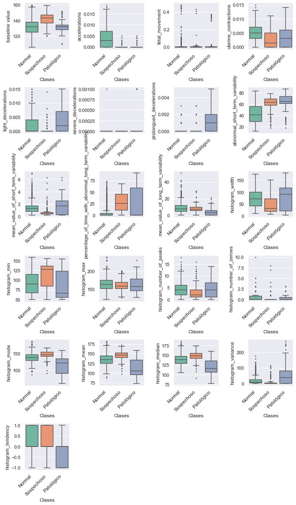

```python
#Boxplot de cada variable en relación a las clases
ds_sinclase=ds_sin_dup.drop("fetal_health",1)
sns.set(palette="Set2")
plt.figure(figsize=(10,17))
i=1
for col in ds_sinclase.columns:
    plt.subplot(6,4,i)
    g2=sns.boxplot(x = 'fetal_health', y= col, data = ds_sin_dup, fliersize=2)
    xlabels = ['Normal','Sospechoso','Patológico']
    g2.set(xlabel='Clases')
    g2.set_xticklabels(xlabels, size=12,  rotation=45, ha='right')
    g2.set
    i+=1
plt.tight_layout()
plt.savefig("Boxplot general.jpg", bbox_inches='tight')
plt.show()
```

La primera conclusión que se puede observar es que hay una gran cantidad de *outliers* en varias de las variables del data set. Esto se tendrá en cuenta en caso de ser necesario optimizar las métricas del modelo de clasificación si las mismas no fueran satifactorias. Otra característica llamativa son dos variables: **fetal movement** y **severe decelerations**, debido a que parecería que la escala de los boxplot no permite visualizar correctamente la distribución de las mismas en cada clase. Para esto se re-graficarán con distinta escala:

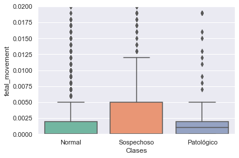

```python
#Grafico la variable fetal_movement aparte ya que en el subplot parecería que la escala de los ejes no permiten ver mucha información
g3=sns.boxplot(x = 'fetal_health', y= "fetal_movement", data = ds_sin_dup)
g3.set(ylim=(0, 0.02))
xlabels = ['Normal','Sospechoso','Patológico']
g3.set_xticklabels(xlabels)
g3.set(xlabel='Clases')
plt.savefig("Boxplot fetal_movement.jpg", bbox_inches='tight')
```

Concluyo dejar esta variable si bien a priori no parece ser clave en la clasificación que se quiere realizar. La distribución de los valores no se comporta de la misma manera en las tres clases, y en las dos primeras no es normal. De todas maneras, se debe tener en cuenta la elevada cantidad de outliers, como se mencionó anteriormente.

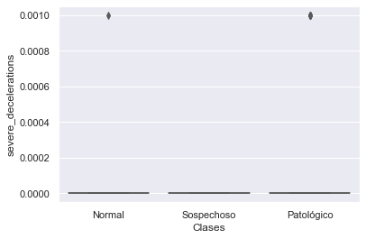

```python
#Grafico la variable severe decelerations aparte ya que en el subplot los cortes de los ejes no permiten ver mucha información
g2=sns.boxplot(x = 'fetal_health', y= "severe_decelerations", data = ds_sin_dup)
xlabels = ['Normal','Sospechoso','Patológico']
g2.set_xticklabels(xlabels)
g2.set(xlabel='Clases')
plt.savefig("Boxplot severe_decelerations.jpg", bbox_inches='tight')
```

En este caso, el gráfico muestra que la mayoría de los registros, para las clases es igual a 0. Lo cual me resulta necesario de seguir analizando.

```python
#Corroboro que hay un único valor distinto de cero en la columna severe decelerations
ds_sin_dup['severe_decelerations'].value_counts()
```

```
0.000    2106
0.001       7
Name: severe_decelerations, dtype: int64
```

```python
#Selecciono aquellos registros correspondientes a los casos Normales, Sospechosos y Patológicos por separado y analizo la variable severe decelerations
ds_1 = ds_sin_dup[ds_sin_dup["fetal_health"] == 1.0]
ds_1
ds_1['severe_decelerations'].value_counts()
```

```
0.000    1645
0.001       1
Name: severe_decelerations, dtype: int64
```

```python
ds_2 = ds_sin_dup[ds_sin_dup["fetal_health"] == 2.0]
ds_2
ds_2['severe_decelerations'].value_counts()
```

```
0.0    292
Name: severe_decelerations, dtype: int64
```

```python
ds_3 = ds_sin_dup[ds_sin_dup["fetal_health"] == 3.0]
ds_3
ds_3['severe_decelerations'].value_counts()
```

```
0.000    169
0.001      6
Name: severe_decelerations, dtype: int64
```

Lo que se puede determinar es que esta variable tiene únicamente dos valores en todo el data set, y aquel distinto de cero tiene únicamente 7 registros en total, por lo tanto considero que no posee información relevante en la clasificación con los datos que se tienen disponibles. No considero realizar una imputación debido a que no hay una cantidad de registros tal que permitan hacer una imputación bajo un sostén de información, sino que sería inventar un valor arbitrario. Se decide eliminar esta variable del data set.

```python
#Elimino la variable severe_decelerations
ds_new=ds_sin_dup.drop("severe_decelerations", 1)
```

Se analizará la distribución de las variables mencionadas anteriormente. Se emplean gráficos de *estimación de la densidad de Kernel* para visualizar la distribución de las observaciones en un set de datos.

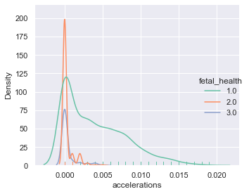

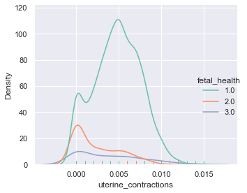

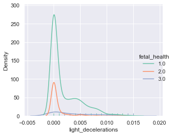

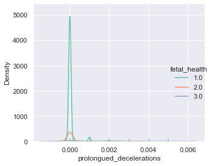

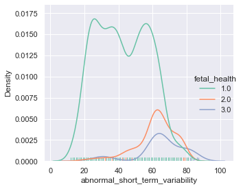

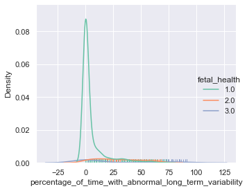

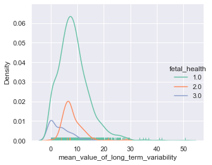

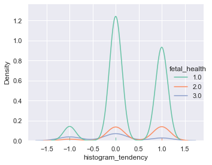

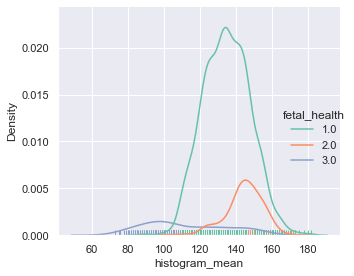

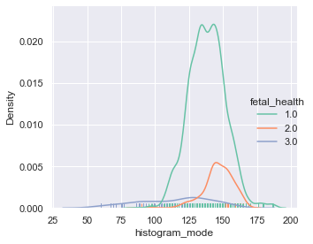

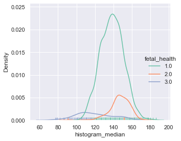

```python
column=["accelerations", "uterine_contractions", "light_decelerations", "prolongued_decelerations", "abnormal_short_term_variability","percentage_of_time_with_abnormal_long_term_variability","mean_value_of_long_term_variability","histogram_tendency", "histogram_mean", "histogram_mode", "histogram_median"]
for column in column:
    plt.figure()
    sns.displot(x=ds_sin_dup[column], data=ds_sin_dup,hue = 'fetal_health', kind="kde", rug=True,height = 4, palette="Set2")
    plt.tight_layout()
    plt.show()
```

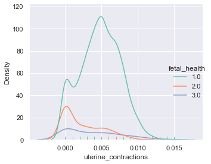

```python
#se repite un de los gráficos anteriores para guardarlo como imagen
sns.displot(x="uterine_contractions", data=ds_sin_dup,hue = 'fetal_health', kind="kde", rug=True,height = 4, palette="Set2")
plt.tight_layout()
plt.savefig("displot.jpg", bbox_inches='tight')
plt.show()
```

Se confirma que estas variables podrían ser claves para la clasificación objetivo.

Para continuar con el análisis exploratorio de los datos se realizará una *matriz de correlación* de manera de poder visualizar rápidamente la relación que existe entre las distintas variables mediante el análisis de la correlación de Pearson:

```python
#Elimino la columna de la clase dentro del set de datos a usar para la correlación
ds_sinclase=ds_sin_dup.drop("fetal_health",1)
ds_sinclase.info()
```

```
<class 'pandas.core.frame.DataFrame'>
Int64Index: 2113 entries, 0 to 2125
Data columns (total 21 columns):
 #   Column                                                  Non-Null Count  Dtype
---  ------                                                  --------------  -----
 0   baseline value                                          2113 non-null   float64
 1   accelerations                                           2113 non-null   float64
 2   fetal_movement                                          2113 non-null   float64
 3   uterine_contractions                                    2113 non-null   float64
 4   light_decelerations                                     2113 non-null   float64
 5   severe_decelerations                                    2113 non-null   float64
 6   prolongued_decelerations                                2113 non-null   float64
 7   abnormal_short_term_variability                         2113 non-null   float64
 8   mean_value_of_short_term_variability                    2113 non-null   float64
 9   percentage_of_time_with_abnormal_long_term_variability  2113 non-null   float64
 10  mean_value_of_long_term_variability                     2113 non-null   float64
 11  histogram_width                                         2113 non-null   float64
 12  histogram_min                                           2113 non-null   float64
 13  histogram_max                                           2113 non-null   float64
 14  histogram_number_of_peaks                               2113 non-null   float64
 15  histogram_number_of_zeroes                              2113 non-null   float64
 16  histogram_mode                                          2113 non-null   float64
 17  histogram_mean                                          2113 non-null   float64
 18  histogram_median                                        2113 non-null   float64
 19  histogram_variance                                      2113 non-null   float64
 20  histogram_tendency                                      2113 non-null   float64
dtypes: float64(21)
memory usage: 427.7 KB
```

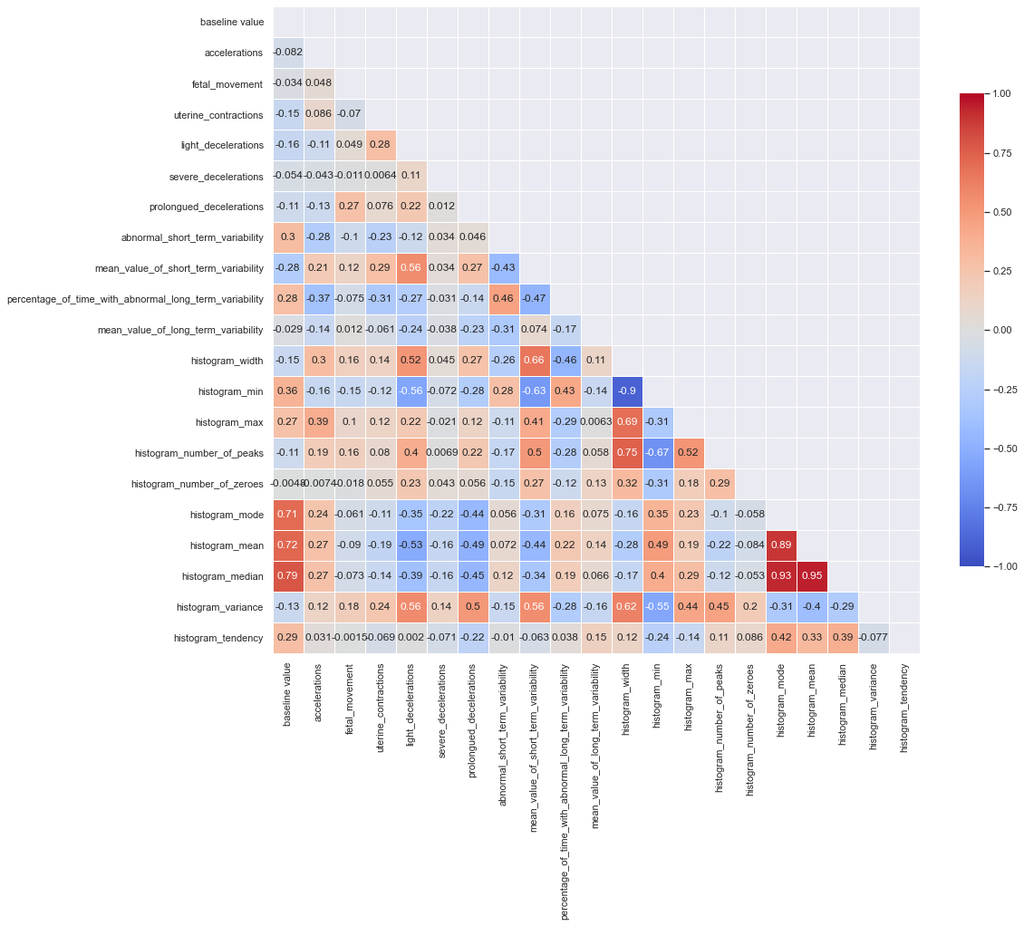

```python
# Matriz de correlación
corr = ds_sinclase.corr()
# Se genera una máscara para el triángulo superior
mask = np.triu(np.ones_like(corr, dtype=bool))

# Seteo de la figura
f, ax = plt.subplots(figsize=(16, 16))

# Definir el mapa de color
cmap = "coolwarm"

# Gráfico de el heatmap con la máscara y el aspecto correcto
sns.set_theme(style="white")
sns.heatmap(corr, mask=mask, cmap=cmap, vmax=1, vmin=-1, center=0,
            square=True, linewidths=.5, cbar_kws={"shrink": .6}, annot=True)
plt.savefig("Matriz Correlación.jpg", bbox_inches='tight')
plt.show()
```

El gráfico de correlación realizado no permite sacar concluciones muy relevante para el objetivo del trabajo. Se puede ver que no hay una correlación muy fuerte entre la mayoría de las variables estudiadas. Algunas de las variables que si mostraron coeficientes altos de correlación fueron: **histogram mean** y **histogram mode** con una correlación positiva y alta, a su vez, **histogram median** con **histogram mode** y **histogram mean**. La otra relación que también es llamativa es entre la **baseline value** y el **histogram median**. Luego, hay una correlación positiva, tal vez no tan fuerte pero si llamativa entre **histogram number of peaks** y la variable **histogram width**. Por último hay una correlación negativa muy fuerte entre el **histogram min** y el **histogram width**.

A continuación, con el objetivo de unificar aquellas variables muy correlacionadas, para ver si se podía, a nivel interpretativo simplificar su aporte al data set, se realizó un **Análisis de Componentes Principales (PCA)**, teniendo en cuenta que en realidad el número de variables no es tan elevada como para precisar una técnica de reducción de dimensionalidad. De todas maneras, a priori se puede ver que el resto de las variables guardan poca correlación entre ellas, y por ende es muy difícil que un PCA logre efectivamente reducir el número de variables necesarias.

```python
#Se realiza un PCA
# Estandarizamos las variables
from sklearn.preprocessing import StandardScaler
sc = StandardScaler()
x_std = sc.fit_transform(ds_sinclase)
print(np.mean(x_std))
print(np.std(x_std)) #El prom debe ser 0 y el sd 1
```

```
7.686217140262054e-18
1.0
```

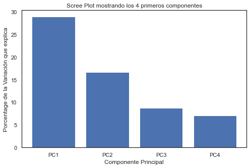

```python
# realizamos un analisis de componentes principales para 4 componentes
from sklearn.decomposition import PCA
pca = PCA(n_components=4)
pca.fit_transform(x_std)

# nos basamos en el scree plot para ver con cuantas variables nos quedamos
percent_var = np.round(pca.explained_variance_ratio_*100, decimals=1)   #calculamos el porcentaje de la variación para cada componente
labels = ['PC'+str(p) for p in range(1,len(percent_var)+1)]

# grafico para ver la contibución de cada uno de los componentes
f, ax = plt.subplots(figsize=(8,5))
plt.bar(x=range(1,len(percent_var)+1), height=percent_var, tick_label=labels)
plt.xlabel('Componente Principal')
plt.ylabel('Porcentage de la Variación que explica')
plt.title('Scree Plot mostrando los 4 primeros componentes')
plt.savefig("PCA.jpg", bbox_inches='tight')
plt.show()
```

```python
explained_var = pca.explained_variance_ratio_
explained_var
```

```
array([0.28860247, 0.16723956, 0.08659547, 0.07092018])
```

```python
cum_var = np.cumsum(np.round(explained_var, decimals = 3))
cum_var_perc = cum_var*100
```

```python
# creamos un dataframe con los 3 componentes
pc_df = pd.DataFrame(['PC1','PC2', 'PC3', "PC4"], columns=['PC'])
explained_var_df = pd.DataFrame(explained_var, columns=['Explained variance'])
cum_var_df = pd.DataFrame(cum_var_perc, columns=['Cumulative variance (in %)'])
```

```python
total_var_explained = pd.concat([pc_df, explained_var_df, cum_var_df], axis=1)
total_var_explained
```

|  | PC | Explained variance | Cumulative variance (in %) |
| --- | --- | --- | --- |
| 0 | PC1 | 0.288602 | 28.9 |
| 1 | PC2 | 0.167240 | 45.6 |
| 2 | PC3 | 0.086595 | 54.3 |
| 3 | PC4 | 0.070920 | 61.4 |

Lo que puedo observar es que, tal como se esperaba, la variancia acumulada con la componente número 4 es del 61.4%, esto lo que indica es que para poder ver representado un porcentaje relevante de variabilidad de datos, que justifique la aplicación del PCA debo emplear un número de componentes principales tales que hacen que no tenga sentido aplicar este método de reducción de la dimensionalidad con este data set. Se concluye no proseguir por este camino.

## Tratamiento del desbalanceo de las clases

Para solucionar el desbalanceo de las clases se optó por probar tres métodos.

1- En primera instancia con **Oversampling de la clase minoritaria**. Se empleará el método **RandomOversample** de la librería **imblearn**.

2- Luego se intentará realizar el balanceo aplicando **Undersampling** y disminuyendo así la clase mayoritaria.

3- Se aplicará en simultáneo un algoritmo de undersampling y otro de oversampling a la vez al dataset. **SMOTE**(Synthetic Minority Oversampling TEchnique) para oversampling y **Tomek** para undersampling.

```python
#División de las columnas del data set en target (y=fetal_health) y predictoras (x)
y = ds_sin_dup.fetal_health
x = ds_new.drop('fetal_health', axis =1)
```

```python
y
```

```
0       2.0
1       1.0
2       1.0
3       1.0
4       1.0
       ...
2121    2.0
2122    2.0
2123    2.0
2124    2.0
2125    1.0
Name: fetal_health, Length: 2113, dtype: float64
```

```python
#Separo en 80% train y 20% test set
from sklearn.model_selection import train_test_split
X_train, X_test, y_train, y_test = train_test_split(x, y, test_size=0.2, random_state=1)
```

```python
y_test.describe()
```

```
count    423.000000
mean       1.293144
std        0.583441
min        1.000000
25%        1.000000
50%        1.000000
75%        1.000000
max        3.000000
Name: fetal_health, dtype: float64
```

```python
y_train.describe()
```

```
count    1690.000000
mean        1.306509
std         0.621896
min         1.000000
25%         1.000000
50%         1.000000
75%         1.000000
max         3.000000
Name: fetal_health, dtype: float64
```

### Oversampling

```python
#Tratamiento del desbalanceo con Oversampling
from imblearn.over_sampling import RandomOverSampler
os =  RandomOverSampler(sampling_strategy="auto", random_state=42)
X_train_res, y_train_res = os.fit_resample(X_train, y_train)

#genero un nuevo dataset con las clases balanceadas

ds_sin_dup_os=y_train_res
ds_new_os=X_train_res
```

```python
columns = ["fetal_health"]
ds_sin_dup_os = pd.DataFrame(ds_sin_dup_os, columns=columns)
```

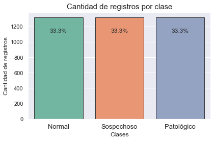

```python
#Gráfico de barras nuevo indicando cantidad total de cada clase con el balanceo aplicado.
sns.set(palette="Set2")
g=sns.countplot(x="fetal_health",data=ds_sin_dup_os, edgecolor=".2")

#títulos y nombres ejes
xlabels = ['Normal','Sospechoso','Patológico']
g.set_xticklabels(xlabels, size=13)
g.set(xlabel='Clases', ylabel='Cantidad de registros')

#porcentajes
total = len(ds_sin_dup_os)
for p in g.patches:
    percentage = f'{100 * p.get_height() / total:.1f}%\n'
    x = p.get_x() + p.get_width() / 2
    y = p.get_height()
    g.annotate(percentage, (x, 1100), ha='center', va='center')

plt.title('Cantidad de registros por clase', fontsize=15)
plt.tight_layout()
plt.savefig("Oversampling clases.jpg", bbox_inches='tight')
plt.show()
```

Las clases tienen ahora el mismo porcentaje de registros.

```python
#Cuenta rápida para chequear porcentajes del gráfico. Esta OK
np.sum(ds_sin_dup_os['fetal_health'] == 1.0)
```

```
1319
```

```python
ds_sin_dup_os.describe()
```

|  | fetal_health |
| --- | --- |
| count | 3957.0000 |
| mean | 2.0000 |
| std | 0.8166 |
| min | 1.0000 |
| 25% | 1.0000 |
| 50% | 2.0000 |
| 75% | 3.0000 |
| max | 3.0000 |

Luego del balanceo de clases el data set quedó con 3957 registros totales.

```python
ds_new_os.describe()
```

|  | baseline value | accelerations | fetal_movement | uterine_contractions | light_decelerations | prolongued_decelerations | abnormal_short_term_variability | mean_value_of_short_term_variability | percentage_of_time_with_abnormal_long_term_variability | mean_value_of_long_term_variability | histogram_width | histogram_min | histogram_max | histogram_number_of_peaks | histogram_number_of_zeroes | histogram_mode | histogram_mean | histogram_median | histogram_variance | histogram_tendency |
| --- | --- | --- | --- | --- | --- | --- | --- | --- | --- | --- | --- | --- | --- | --- | --- | --- | --- | --- | --- | --- |
| count | 3957.000000 | 3957.000000 | 3957.000000 | 3957.000000 | 3957.000000 | 3957.000000 | 3957.000000 | 3957.000000 | 3957.000000 | 3957.000000 | 3957.000000 | 3957.000000 | 3957.00000 | 3957.000000 | 3957.000000 | 3957.000000 | 3957.000000 | 3957.000000 | 3957.000000 | 3957.000000 |
| mean | 134.833965 | 0.001553 | 0.013851 | 0.003722 | 0.002140 | 0.000460 | 56.602982 | 1.221026 | 19.330806 | 6.598509 | 66.855951 | 95.917109 | 162.77306 | 3.997726 | 0.318170 | 132.557746 | 130.457165 | 134.455901 | 25.231741 | 0.227950 |
| std | 10.224279 | 0.002980 | 0.059518 | 0.003203 | 0.003379 | 0.001008 | 16.904712 | 1.022827 | 26.272181 | 5.173161 | 44.799813 | 33.504806 | 19.05199 | 3.147494 | 0.735222 | 22.894381 | 21.224664 | 19.001753 | 42.142545 | 0.667835 |
| min | 106.000000 | 0.000000 | 0.000000 | 0.000000 | 0.000000 | 0.000000 | 12.000000 | 0.200000 | 0.000000 | 0.000000 | 3.000000 | 50.000000 | 122.00000 | 0.000000 | 0.000000 | 60.000000 | 73.000000 | 77.000000 | 0.000000 | -1.000000 |
| 25% | 128.000000 | 0.000000 | 0.000000 | 0.000000 | 0.000000 | 0.000000 | 45.000000 | 0.400000 | 0.000000 | 3.500000 | 24.000000 | 63.000000 | 151.00000 | 1.000000 | 0.000000 | 124.000000 | 120.000000 | 123.000000 | 1.000000 | 0.000000 |
| 50% | 134.000000 | 0.000000 | 0.000000 | 0.003000 | 0.000000 | 0.000000 | 61.000000 | 0.900000 | 4.000000 | 6.100000 | 64.000000 | 99.000000 | 159.00000 | 3.000000 | 0.000000 | 138.000000 | 135.000000 | 138.000000 | 4.000000 | 0.000000 |
| 75% | 143.000000 | 0.002000 | 0.003000 | 0.006000 | 0.003000 | 0.000000 | 67.000000 | 1.800000 | 33.000000 | 9.100000 | 104.000000 | 129.000000 | 174.00000 | 6.000000 | 0.000000 | 148.000000 | 147.000000 | 149.000000 | 33.000000 | 1.000000 |
| max | 160.000000 | 0.019000 | 0.481000 | 0.014000 | 0.015000 | 0.005000 | 87.000000 | 6.900000 | 91.000000 | 50.700000 | 180.000000 | 159.000000 | 238.00000 | 18.000000 | 10.000000 | 186.000000 | 182.000000 | 186.000000 | 254.000000 | 1.000000 |

### Undersampling

```python
#Tratamiento del desbalanceo con Undersampling
from imblearn.under_sampling import RandomUnderSampler

#Tratamiento del desbalanceo
us =  RandomUnderSampler(sampling_strategy="auto", random_state=42)
X_train_us, y_train_us = us.fit_resample(X_train, y_train)

#genero un nuevo dataset con las clases balanceadas
ds_sin_dup_us=y_train_us
ds_new_us=X_train_us
```

```python
columns = ["fetal_health"]
ds_sin_dup_us = pd.DataFrame(ds_sin_dup_us, columns=columns)
```

```python
ds_sin_dup_us.describe()
```

|  | fetal_health |
| --- | --- |
| count | 441.000000 |
| mean | 2.000000 |
| std | 0.817424 |
| min | 1.000000 |
| 25% | 1.000000 |
| 50% | 2.000000 |
| 75% | 3.000000 |
| max | 3.000000 |

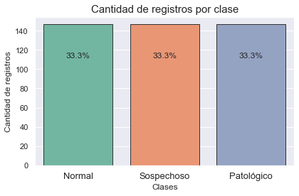

```python
#Gráfico de barras nuevo indicando cantidad total de cada clase con el balanceo aplicado.
sns.set(palette="Set2")
g=sns.countplot(x="fetal_health",data=ds_sin_dup_us, edgecolor=".2")

#títulos y nombres ejes
xlabels = ['Normal','Sospechoso','Patológico']
g.set_xticklabels(xlabels, size=13)
g.set(xlabel='Clases', ylabel='Cantidad de registros')

#porcentajes
total = len(ds_sin_dup_us)
for p in g.patches:
    percentage = f'{100 * p.get_height() / total:.1f}%\n'
    x = p.get_x() + p.get_width() / 2
    y = p.get_height()
    g.annotate(percentage, (x, 110), ha='center', va='center')

plt.title('Cantidad de registros por clase', fontsize=15)
plt.tight_layout()
plt.savefig("Undersampling clases.jpg", bbox_inches='tight')
plt.show()
```

```python
#Cuenta rápida para chequear porcentajes del gráfico. Esta OK
np.sum(ds_sin_dup_us['fetal_health'] == 1.0)
```

```
147
```

Vemos que el número total de registros disminuyó muchísimo en el set de entrenamiento: 147 para cada clase.

### SMOTETomek

SMOTE:"Synthetic Minority Oversampling TEchnique"

```python
#Tratamiento de las clases con SMOTETomek
from imblearn.combine import SMOTETomek

os_us = SMOTETomek(sampling_strategy="auto", random_state=42)
X_train_os_us, y_train_os_us = os_us.fit_resample(X_train, y_train)
```

```python
#genero un nuevo dataset con las clases balanceadas
ds_sin_dup_os_us=y_train_os_us
ds_new_os_us=X_train_os_us
```

```python
columns = ["fetal_health"]
ds_sin_dup_os_us = pd.DataFrame(ds_sin_dup_os_us, columns=columns)
```

```python
ds_sin_dup_os_us.describe()
```

|  | fetal_health |
| --- | --- |
| count | 3941.000000 |
| mean | 2.001776 |
| std | 0.816857 |
| min | 1.000000 |
| 25% | 1.000000 |
| 50% | 2.000000 |
| 75% | 3.000000 |
| max | 3.000000 |

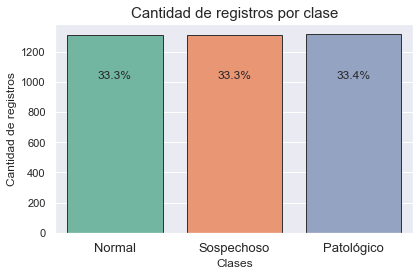

```python
#Gráfico de barras nuevo indicando cantidad total de cada clase con el balanceo aplicado.
sns.set(palette="Set2")
g=sns.countplot(x="fetal_health",data=ds_sin_dup_os_us, edgecolor=".2")

#títulos y nombres ejes
xlabels = ['Normal','Sospechoso','Patológico']
g.set_xticklabels(xlabels, size=13)
g.set(xlabel='Clases', ylabel='Cantidad de registros')

#porcentajes
total = len(ds_sin_dup_os_us)
for p in g.patches:
    percentage = f'{100 * p.get_height() / total:.1f}%\n'
    x = p.get_x() + p.get_width() / 2
    y = p.get_height()
    g.annotate(percentage, (x,1000), ha='center', va='center')

plt.title('Cantidad de registros por clase', fontsize=15)
plt.tight_layout()
plt.savefig("SMOOTETomek clases.jpg", bbox_inches='tight')
plt.show()
```

```python
#Cuenta rápida para chequear porcentajes del gráfico. Esta OK
np.sum(ds_sin_dup_os_us['fetal_health'] == 1.0)
```

```
1311
```

Luego del balanceo el dataset quedó con 3941 registros y el mismo porcentaje de registros en cada clase.

## GridSearch

Se buscan los mejores hiperparámetros para los modelos de Random Forest y AdaBoost de clasificación que se aplicarán a continuación:

```python
from sklearn.model_selection import GridSearchCV
```

## Modelo de clasificación

Para cada set de datos con los distintos tipos de balanceo de clases, asimismo para los datos sin balancear se aplicará **Random Forest** para comparar. Luego se aplicará con los datos balanceados por uno de los métodos aplicados, el método de ensamble **AdaBoost** para verificar si se observa una mejora en las métricas.

### Sin balancear clases

En primer lugar se intentará aplicar el modelo de Random Forest en el data set original, con las clases sin balancear, para comparar luego con el tratamiento de balanceo clases. Se buscan los mejores parámetros para este caso.

```python
#Definicion de Hyperparámetros
param_grid = {'n_estimators': [60, 100, 120, 150],
    'max_features': ['auto'],
    'max_depth' : [2,3,4],
    'criterion' :['gini']}

model_nobalance = RandomForestClassifier(random_state=1)

#Utilizamos la grilla definida anteriormente
cv=StratifiedKFold(n_splits=5)
model_nobalance_GSCV = GridSearchCV(estimator=model_nobalance, param_grid=param_grid, cv=cv)

model_nobalance_GSCV.fit(X_train,y_train)
```

```
GridSearchCV(cv=StratifiedKFold(n_splits=5, random_state=None, shuffle=False),
             estimator=RandomForestClassifier(random_state=1),
             param_grid={'criterion': ['gini'], 'max_depth': [2, 3, 4],
                         'max_features': ['auto'],
                         'n_estimators': [60, 100, 120, 150]})
```

```python
model_nobalance_GSCV.best_params_
```

```
{'criterion': 'gini',
 'max_depth': 4,
 'max_features': 'auto',
 'n_estimators': 60}
```

```python
#Corro el modelo con los parámetros selecionados.
model_nobalance_best=RandomForestClassifier(random_state=1, max_features='auto', n_estimators= 60, max_depth=4, criterion='gini')
```

```python
#Aplico los valores del Dataset que quiero analizar
model_nobalance_best.fit(X_train,y_train)

pred_nobalance = model_nobalance_best.predict(X_test)
pred_nobalance
from sklearn import metrics
nobalance=metrics.accuracy_score(y_test, pred_nobalance)
nb_f1=metrics.f1_score(y_test, pred_nobalance, average=None)
nb_p=metrics.precision_score(y_test, pred_nobalance, average=None)
nb_r=metrics.recall_score(y_test, pred_nobalance, average=None)
print("Accuracy:",metrics.accuracy_score(y_test, pred_nobalance))
```

```
Accuracy: 0.8912529550827423
```

```python
nb_p_df=pd.DataFrame(nb_p, columns=["Precisión"])
nb_p_df["Clase"] = ["Normal", "Sospechoso", "Patológico"]
nb_p_df
```

|  | Precisión | Clase |
| --- | --- | --- |
| 0 | 0.892857 | Normal |
| 1 | 0.840909 | Sospechoso |
| 2 | 1.000000 | Patológico |

```python
nb_f1_df=pd.DataFrame(nb_f1, columns=["Score F1"])
nb_f1_df["Clase"] = ["Normal", "Sospechoso", "Patológico"]
nb_f1_df
```

|  | Score F1 | Clase |
| --- | --- | --- |
| 0 | 0.940666 | Normal |
| 1 | 0.660714 | Sospechoso |
| 2 | 0.697674 | Patológico |

```python
nb_r_df=pd.DataFrame(nb_r, columns=["Sensibilidad"])
nb_r_df["Clase"] = ["Normal", "Sospechoso", "Patológico"]
nb_r_df
```

|  | Sensibilidad | Clase |
| --- | --- | --- |
| 0 | 0.993884 | Normal |
| 1 | 0.544118 | Sospechoso |
| 2 | 0.535714 | Patológico |

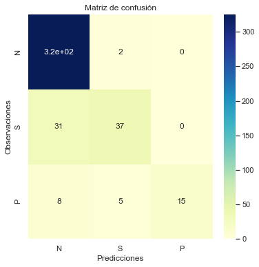

```
              precision    recall  f1-score   support

         1.0       0.89      0.99      0.94       327
         2.0       0.84      0.54      0.66        68
         3.0       1.00      0.54      0.70        28

    accuracy                           0.89       423
   macro avg       0.91      0.69      0.77       423
weighted avg       0.89      0.89      0.88       423
```

```python
#Armamos la matriz de confusión
from sklearn.metrics import confusion_matrix
from sklearn.metrics import classification_report
def mostrar_resultados(y_test, pred_nobalance):
    conf_matrix1 = confusion_matrix(y_test, pred_nobalance)
    plt.figure(figsize=(6, 6))
    cm1=sns.heatmap(conf_matrix1, cmap="YlGnBu", xticklabels="NSP", yticklabels="NSP", annot=True);
    plt.title("Matriz de confusión")
    plt.ylabel('Observaciones')
    plt.xlabel('Predicciones')
    plt.savefig("Matriz1.jpg", bbox_inches='tight')
    plt.show()

    print (classification_report(y_test, pred_nobalance))

mostrar_resultados(y_test, pred_nobalance)
```

Se puede ver que si no se balancean las clases, el accuracy da bastante alto, pero se presenta cierto problema al clasificar los sospechosos y los casos patológicos ya que algunos se pierden y se los clasifica erronamente (baja sensibilidad), en general como normales, lo cual a nivel médico es un problema. En el caso de los patológicos esto representa un problema aún mayor. Además para los casos normales la precisión es alta y la sensibilidad es casi 1, se puede ver en la matriz de confusión que practicamente todas las observaciones se clasifican como normales, lo cual es esperable dado que es la clase mayoritaria .

### Random Forest con oversampling

```python
#Definicion de Hyperparámetros
param_grid = {'n_estimators': [60, 100, 120, 150],
    'max_features': ['auto'],
    'max_depth' : [2,3,4],
    'criterion' :['gini']}

model1 = RandomForestClassifier(random_state=1)

#Utilizamos la grilla definida anteriormente
cv=StratifiedKFold(n_splits=5)
model_GSCV = GridSearchCV(estimator=model1, param_grid=param_grid, cv=cv)

model_GSCV.fit(X_train_res,y_train_res)
```

```
GridSearchCV(cv=StratifiedKFold(n_splits=5, random_state=None, shuffle=False),
             estimator=RandomForestClassifier(random_state=1),
             param_grid={'criterion': ['gini'], 'max_depth': [2, 3, 4],
                         'max_features': ['auto'],
                         'n_estimators': [60, 100, 120, 150]})
```

```python
model_GSCV.best_params_
```

```
{'criterion': 'gini',
 'max_depth': 4,
 'max_features': 'auto',
 'n_estimators': 60}
```

```python
#Corro el modelo con los parámetros selecionados
model_best=RandomForestClassifier(random_state=1, max_features='auto', n_estimators= 60, max_depth=4, criterion='gini')
```

```python
#Aplico los valores del Dataset que quiero analizar
model_best.fit(X_train_res,y_train_res)

pred = model_best.predict(X_test)
pred
from sklearn import metrics
RFos=metrics.accuracy_score(y_test, pred)
os_f1=metrics.f1_score(y_test, pred, average=None)
os_p=metrics.precision_score(y_test, pred, average=None)
os_r=metrics.recall_score(y_test, pred, average=None)
print("Accuracy:",metrics.accuracy_score(y_test, pred))
```

```
Accuracy: 0.8770685579196218
```

```python
os_p_df=pd.DataFrame(os_p, columns=["Precisión"])
os_p_df["Clase"] = ["Normal", "Sospechoso", "Patológico"]
os_p_df
```

|  | Precisión | Clase |
| --- | --- | --- |
| 0 | 0.963934 | Normal |
| 1 | 0.612903 | Sospechoso |
| 2 | 0.800000 | Patológico |

```python
os_f1_df=pd.DataFrame(os_f1, columns=["Score F1"])
os_f1_df["Clase"] = ["Normal", "Sospechoso", "Patológico"]
os_f1_df
```

|  | Score F1 | Clase |
| --- | --- | --- |
| 0 | 0.930380 | Normal |
| 1 | 0.708075 | Sospechoso |
| 2 | 0.754717 | Patológico |

```python
os_r_df=pd.DataFrame(os_r, columns=["Sensibilidad"])
os_r_df["Clase"] = ["Normal", "Sospechoso", "Patológico"]
os_r_df
```

|  | Sensibilidad | Clase |
| --- | --- | --- |
| 0 | 0.899083 | Normal |
| 1 | 0.838235 | Sospechoso |
| 2 | 0.714286 | Patológico |

Vamos a graficar la matriz de confusión luego del balanceo de clases con oversampling y el modelo de RF con los parámetros ajustados.

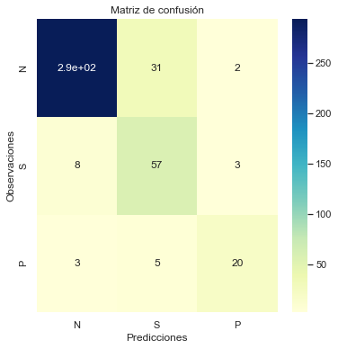

```
              precision    recall  f1-score   support

         1.0       0.96      0.90      0.93       327
         2.0       0.61      0.84      0.71        68
         3.0       0.80      0.71      0.75        28

    accuracy                           0.88       423
   macro avg       0.79      0.82      0.80       423
weighted avg       0.90      0.88      0.88       423
```

```python
#Armamos la matriz de confusión
from sklearn.metrics import confusion_matrix
from sklearn.metrics import classification_report
def mostrar_resultados(y_test, pred):
    conf_matrix2 = confusion_matrix(y_test, pred)
    plt.figure(figsize=(6, 6))
    cm2=sns.heatmap(conf_matrix2, cmap="YlGnBu", xticklabels="NSP", yticklabels="NSP", annot=True);
    plt.title("Matriz de confusión")
    plt.ylabel('Observaciones')
    plt.xlabel('Predicciones')
    plt.savefig("Matriz 2.jpg", bbox_inches='tight')
    plt.show()

    print (classification_report(y_test, pred))

mostrar_resultados(y_test, pred)
```

En este caso si bien la accuracy es similar al caso anterior, la sensibilidad (recall) de los sospechosos y patológicos es mejor que sin balancear. Sin embargo aún se podría mejorar la precisión ya que se asignan varios casos normales como sospechosos. A mi criterio, esto último puede ocasionar que algunos casos normales se estudien con más profundidad lo cual no sería tan grave, y al menos los casos sospechosos son detectados con más sensibilidad que sin balancear las clases. El tema a mejorar podría ser para el caso de los patológicos, que sería lo más grave, intentar mejorar un poco la sensibilidad.

### Random Forest con undersampling

En este caso se aplicará el modelo Random Forest sobre los datos balanceados con undersampling

```python
#Definicion de Hyperparámetros
param_grid = {'n_estimators': [60, 100, 120, 150],
    'max_features': ['auto'],
    'max_depth' : [2,3,4],
    'criterion' :['gini']}

model2 = RandomForestClassifier(random_state=1)

#Utilizamos la grilla definida anteriormente
cv=StratifiedKFold(n_splits=5)
model_us_GSCV = GridSearchCV(estimator=model2, param_grid=param_grid, cv=cv)

model_us_GSCV.fit(X_train_us,y_train_us)
```

```
GridSearchCV(cv=StratifiedKFold(n_splits=5, random_state=None, shuffle=False),
             estimator=RandomForestClassifier(random_state=1),
             param_grid={'criterion': ['gini'], 'max_depth': [2, 3, 4],
                         'max_features': ['auto'],
                         'n_estimators': [60, 100, 120, 150]})
```

```python
model_us_GSCV.best_params_
```

```
{'criterion': 'gini',
 'max_depth': 4,
 'max_features': 'auto',
 'n_estimators': 60}
```

```python
#Corro el modelo con los parámetros selecionados
model_us_best=RandomForestClassifier(random_state=1, max_features='auto', n_estimators= 60, max_depth=4, criterion='gini')
```

```python
#Aplico los valores del Dataset que quiero analizar
model_us_best.fit(X_train_us,y_train_us)

pred_us = model_us_best.predict(X_test)
pred_us
from sklearn import metrics
RFus=metrics.accuracy_score(y_test, pred_us)
us_f1=metrics.f1_score(y_test, pred_us, average=None)
us_p=metrics.precision_score(y_test, pred_us, average=None)
us_r=metrics.recall_score(y_test, pred_us, average=None)
print("Accuracy:",metrics.accuracy_score(y_test, pred_us))
```

```
Accuracy: 0.8652482269503546
```

```python
us_p_df=pd.DataFrame(us_p, columns=["Precisión"])
us_p_df["Clase"] = ["Normal", "Sospechoso", "Patológico"]
us_p_df
```

|  | Precisión | Clase |
| --- | --- | --- |
| 0 | 0.960133 | Normal |
| 1 | 0.604167 | Sospechoso |
| 2 | 0.730769 | Patológico |

```python
us_f1_df=pd.DataFrame(us_f1, columns=["Score F1"])
us_f1_df["Clase"] = ["Normal", "Sospechoso", "Patológico"]
us_f1_df
```

|  | Score F1 | Clase |
| --- | --- | --- |
| 0 | 0.920382 | Normal |
| 1 | 0.707317 | Sospechoso |
| 2 | 0.703704 | Patológico |

```python
us_r_df=pd.DataFrame(us_r, columns=["Sensibilidad"])
us_r_df["Clase"] = ["Normal", "Sospechoso", "Patológico"]
us_r_df
```

|  | Sensibilidad | Clase |
| --- | --- | --- |
| 0 | 0.883792 | Normal |
| 1 | 0.852941 | Sospechoso |
| 2 | 0.678571 | Patológico |

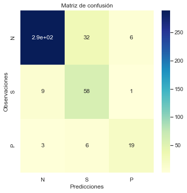

```
              precision    recall  f1-score   support

         1.0       0.96      0.88      0.92       327
         2.0       0.60      0.85      0.71        68
         3.0       0.73      0.68      0.70        28

    accuracy                           0.87       423
   macro avg       0.77      0.81      0.78       423
weighted avg       0.89      0.87      0.87       423
```

```python
#Armamos la matriz de confusión
def mostrar_resultados(y_test, pred_us):
    conf_matrix3 = confusion_matrix(y_test, pred_us)
    plt.figure(figsize=(6, 6))
    cm3=sns.heatmap(conf_matrix3, cmap="YlGnBu", xticklabels="NSP", yticklabels="NSP", annot=True);
    plt.title("Matriz de confusión")
    plt.ylabel('Observaciones')
    plt.xlabel('Predicciones')
    plt.savefig("Matriz3.jpg", bbox_inches='tight')
    plt.show()

    print (classification_report(y_test, pred_us))

mostrar_resultados(y_test, pred_us)
```

Podemos ver que, hay bajo número de registros que quedan en el train dataset luego del resample. Para la clase sospechosos la presición es bastante baja, es decir, tiende a clasificar otros casos como casos sospechosos, que si bien puede implicar un problema, no sería tan grave medicamente. Luego el recall es bueno. Para el caso de patológicos, podemos ver que el recall es más alto que sin balancear, lo cual indica que más casos patológicos serán clasificados como tales, sin embargo, es levemente más baja que con oversampling. Además la precisión baja en relación a sin balancear, lo cual refleja que se indicarán como patológicos varios casos que en realidad son normales. Considero que este método de balanceo de clases si bien presenta buena sensibilidad en todas las clases, la de la clase patológica se podría mejorar aún más y además el método **no sería el indicado para este dataset** principalmente por que se estaría entrenando el modelo con 441 registros únicamente, lo cual es muy poco y tal vez otro método de balanceo de clases logre un balance de sensibilidad y precisión mejor para la clase patológica.

### Random Forest con combinación over y under sampling

Se aplicará el modelo de Random Forest trabajando con las clases balanceadas por el método de SMOTE Tomek.

```python
#Definicion de Hyperparámetros
param_grid = {'n_estimators': [60, 100, 120, 150],
    'max_features': ['auto'],
    'max_depth' : [2,3,4],
    'criterion' :['gini']}

model3 = RandomForestClassifier(random_state=1)

#Utilizamos la grilla definida anteriormente
cv=StratifiedKFold(n_splits=5)
model_os_us_GSCV = GridSearchCV(estimator=model3, param_grid=param_grid, cv=cv)

model_os_us_GSCV.fit(X_train_os_us,y_train_os_us)
```

```
GridSearchCV(cv=StratifiedKFold(n_splits=5, random_state=None, shuffle=False),
             estimator=RandomForestClassifier(random_state=1),
             param_grid={'criterion': ['gini'], 'max_depth': [2, 3, 4],
                         'max_features': ['auto'],
                         'n_estimators': [60, 100, 120, 150]})
```

```python
model_os_us_GSCV.best_params_
```

```
{'criterion': 'gini',
 'max_depth': 4,
 'max_features': 'auto',
 'n_estimators': 150}
```

```python
#Corro el modelo con los parámetros selecionados
model_os_us_best=RandomForestClassifier(random_state=1, max_features='auto', n_estimators= 150, max_depth=4, criterion='gini')
```

```python
#Aplico los valores del Dataset que quiero analizar
model_os_us_best.fit(X_train_os_us,y_train_os_us)

pred_os_us = model_os_us_best.predict(X_test)
pred_os_us

RFSMOTETomek=metrics.accuracy_score(y_test, pred_os_us)
ST_f1=metrics.f1_score(y_test, pred_os_us, average=None)
ST_p=metrics.precision_score(y_test, pred_os_us, average=None)
ST_r=metrics.recall_score(y_test, pred_os_us, average=None)
print("Accuracy:",metrics.accuracy_score(y_test, pred_os_us))
```

```
Accuracy: 0.8888888888888888
```

```python
ST_p_df=pd.DataFrame(ST_p, columns=["Precisión"])
ST_p_df["Clase"] = ["Normal", "Sospechoso", "Patológico"]
ST_p_df
```

|  | Precisión | Clase |
| --- | --- | --- |
| 0 | 0.964744 | Normal |
| 1 | 0.651163 | Sospechoso |
| 2 | 0.760000 | Patológico |

```python
ST_f1_df=pd.DataFrame(ST_f1, columns=["Score F1"])
ST_f1_df["Clase"] = ["Normal", "Sospechoso", "Patológico"]
ST_f1_df
```

|  | Score F1 | Clase |
| --- | --- | --- |
| 0 | 0.942097 | Normal |
| 1 | 0.727273 | Sospechoso |
| 2 | 0.716981 | Patológico |

```python
ST_r_df=pd.DataFrame(ST_r, columns=["Sensibilidad"])
ST_r_df["Clase"] = ["Normal", "Sospechoso", "Patológico"]
ST_r_df
```

|  | Sensibilidad | Clase |
| --- | --- | --- |
| 0 | 0.920489 | Normal |
| 1 | 0.823529 | Sospechoso |
| 2 | 0.678571 | Patológico |

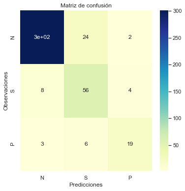

```
              precision    recall  f1-score   support

         1.0       0.96      0.92      0.94       327
         2.0       0.65      0.82      0.73        68
         3.0       0.76      0.68      0.72        28

    accuracy                           0.89       423
   macro avg       0.79      0.81      0.80       423
weighted avg       0.90      0.89      0.89       423
```

```python
#Armamos la matriz de confusión
def mostrar_resultados(y_test, pred_os_us):
    conf_matrix4 = confusion_matrix(y_test, pred_os_us)
    plt.figure(figsize=(6, 6))
    cm4=sns.heatmap(conf_matrix4, cmap="YlGnBu", xticklabels="NSP", yticklabels="NSP", annot=True);
    plt.title("Matriz de confusión")
    plt.ylabel('Observaciones')
    plt.xlabel('Predicciones')
    plt.savefig("Matriz 4.jpg", bbox_inches='tight')
    plt.show()

    print (classification_report(y_test, pred_os_us))

mostrar_resultados(y_test, pred_os_us)
```

Es importante destacar que este tratamiento, en relación a oversampling no parece mostrar mejoras demasiado significativas. Si se observa una mejora notable con respecto a los datos sin balancear principalmente en la sensibilidad.

```python
from sklearn.tree import DecisionTreeClassifier #sirve porque corre dentro del AdaBoost
from sklearn.ensemble import AdaBoostClassifier
```

```python
#Defino parámetros
parameters = {'n_estimators': [50, 100, 120, 200],
              'learning_rate':[0.5,1,1.5]}

abc = AdaBoostClassifier(base_estimator=DecisionTreeClassifier(random_state =1))

cv=StratifiedKFold(n_splits=5)
abc_GS = GridSearchCV(estimator=abc, param_grid=parameters, cv=cv)
abc_GS.fit(X_train_res,y_train_res)
```

```
GridSearchCV(cv=StratifiedKFold(n_splits=5, random_state=None, shuffle=False),
             estimator=AdaBoostClassifier(base_estimator=DecisionTreeClassifier(random_state=1)),
             param_grid={'learning_rate': [0.5, 1, 1.5],
                         'n_estimators': [50, 100, 120, 200]})
```

```python
abc_GS.best_params_
```

```
{'learning_rate': 1, 'n_estimators': 100}
```

```python
#Corro el modelo con los parámetros selecionados
abc_GS_best=AdaBoostClassifier(DecisionTreeClassifier(random_state =1),
                            n_estimators=100,learning_rate=1, random_state =1)
```

```python
#Aplico los valores del Dataset que quiero analizar


#Aplico los valores del Dataset que quiero analizar
abc_GS_best.fit(X_train_os_us,y_train_os_us)

pred_abc = abc_GS_best.predict(X_test)
pred_abc

AdaB=metrics.accuracy_score(y_test, pred_abc)
STada_f1=metrics.f1_score(y_test, pred_abc, average=None)
STada_p=metrics.precision_score(y_test, pred_abc, average=None)
STada_r=metrics.recall_score(y_test, pred_abc, average=None)
print("Accuracy:",metrics.accuracy_score(y_test, pred_abc))
```

```
Accuracy: 0.9314420803782506
```

```python
STada_p_df=pd.DataFrame(STada_p, columns=["Precisión"])
STada_p_df["Clase"] = ["Normal", "Sospechoso", "Patológico"]
STada_p_df
```

|  | Precisión | Clase |
| --- | --- | --- |
| 0 | 0.963415 | Normal |
| 1 | 0.794118 | Sospechoso |
| 2 | 0.888889 | Patológico |

```python
STada_f1_df=pd.DataFrame(STada_f1, columns=["Score F1"])
STada_f1_df["Clase"] = ["Normal", "Sospechoso", "Patológico"]
STada_f1_df
```

|  | Score F1 | Clase |
| --- | --- | --- |
| 0 | 0.964885 | Normal |
| 1 | 0.794118 | Sospechoso |
| 2 | 0.872727 | Patológico |

```python
STada_r_df=pd.DataFrame(STada_r, columns=["Sensibilidad"])
STada_r_df["Clase"] = ["Normal", "Sospechoso", "Patológico"]
STada_r_df
```

|  | Sensibilidad | Clase |
| --- | --- | --- |
| 0 | 0.966361 | Normal |
| 1 | 0.794118 | Sospechoso |
| 2 | 0.857143 | Patológico |

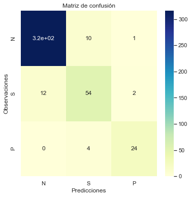

```
              precision    recall  f1-score   support

         1.0       0.96      0.97      0.96       327
         2.0       0.79      0.79      0.79        68
         3.0       0.89      0.86      0.87        28

    accuracy                           0.93       423
   macro avg       0.88      0.87      0.88       423
weighted avg       0.93      0.93      0.93       423
```

```python
#Armamos la matriz de confusión

def mostrar_resultados(y_test, pred_abc):
    conf_matrix5 = confusion_matrix(y_test, pred_abc)
    plt.figure(figsize=(6, 6))
    cm5=sns.heatmap(conf_matrix5, cmap="YlGnBu", xticklabels="NSP", yticklabels="NSP", annot=True);
    plt.title("Matriz de confusión")
    plt.ylabel('Observaciones')
    plt.xlabel('Predicciones')
    plt.savefig("Matriz 5.jpg", bbox_inches='tight')
    plt.show()

    print (classification_report(y_test, pred_abc))

mostrar_resultados(y_test, pred_abc)
```

### Resumen de métricas de los modelos aplicados

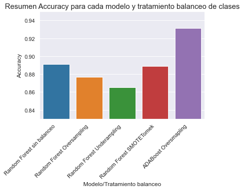

```python
#Resumen accuracy
x = ["Random Forest sin balanceo",
     "Random Forest Oversampling",
     "Random Forest Underampling",
     "Random Forest SMOTETomek",
     "ADABoost Oversmapling"]

y = [nobalance,
     RFos,
     RFus,
     RFSMOTETomek,
     AdaB
    ]

fig = sns.barplot(x=x, y=y)
fig.set(xlabel='Modelo/Tratamiento balanceo', ylabel='Accuracy', ylim=(0.83, 0.95))
plt.xticks(rotation=45, ha='right')
plt.title('Resumen Accuracy para cada modelo y tratamiento balanceo de clases', fontsize=15)
plt.savefig("Resumen accuracy.jpg", bbox_inches='tight')
```

```python
#Armo un dataframe general para resultado de precision
frames_p = [nb_p_df, os_p_df, us_p_df, ST_p_df,STada_p_df ]
result_p = pd.concat(frames_p)
```

```python
result_p["Modelo"] = ["Random Forest sin balanceo","Random Forest sin balanceo", "Random Forest sin balanceo",
     "Random Forest Oversampling", "Random Forest Oversampling", "Random Forest Oversampling",
     "Random Forest Underampling","Random Forest Underampling", "Random Forest Underampling",
     "Random Forest SMOTETomek","Random Forest SMOTETomek", "Random Forest SMOTETomek",
     "ADABoost Oversampling","ADABoost Oversampling","ADABoost Oversampling"]
result_p
```

|  | Precisión | Clase | Modelo |
| --- | --- | --- | --- |
| 0 | 0.892857 | Normal | Random Forest sin balanceo |
| 1 | 0.840909 | Sospechoso | Random Forest sin balanceo |
| 2 | 1.000000 | Patológico | Random Forest sin balanceo |
| 0 | 0.963934 | Normal | Random Forest Oversampling |
| 1 | 0.612903 | Sospechoso | Random Forest Oversampling |
| 2 | 0.800000 | Patológico | Random Forest Oversampling |
| 0 | 0.960133 | Normal | Random Forest Underampling |
| 1 | 0.604167 | Sospechoso | Random Forest Underampling |
| 2 | 0.730769 | Patológico | Random Forest Underampling |
| 0 | 0.964744 | Normal | Random Forest SMOTETomek |
| 1 | 0.651163 | Sospechoso | Random Forest SMOTETomek |
| 2 | 0.760000 | Patológico | Random Forest SMOTETomek |
| 0 | 0.963415 | Normal | ADABoost Oversampling |
| 1 | 0.794118 | Sospechoso | ADABoost Oversampling |
| 2 | 0.888889 | Patológico | ADABoost Oversampling |

```python
#Armo un dataframe general para resultado de f1score
frames_f1 = [nb_f1_df, os_f1_df, us_f1_df, ST_f1_df,STada_f1_df ]
result_f1 = pd.concat(frames_f1)
result_f1["Modelo"] = ["Random Forest sin balanceo","Random Forest sin balanceo", "Random Forest sin balanceo",
     "Random Forest Oversampling", "Random Forest Oversampling", "Random Forest Oversampling",
     "Random Forest Underampling","Random Forest Underampling", "Random Forest Underampling",
     "Random Forest SMOTETomek","Random Forest SMOTETomek", "Random Forest SMOTETomek",
     "ADABoost Oversampling","ADABoost Oversampling","ADABoost Oversampling"]
result_f1
```

|  | Score F1 | Clase | Modelo |
| --- | --- | --- | --- |
| 0 | 0.940666 | Normal | Random Forest sin balanceo |
| 1 | 0.660714 | Sospechoso | Random Forest sin balanceo |
| 2 | 0.697674 | Patológico | Random Forest sin balanceo |
| 0 | 0.930380 | Normal | Random Forest Oversampling |
| 1 | 0.708075 | Sospechoso | Random Forest Oversampling |
| 2 | 0.754717 | Patológico | Random Forest Oversampling |
| 0 | 0.920382 | Normal | Random Forest Underampling |
| 1 | 0.707317 | Sospechoso | Random Forest Underampling |
| 2 | 0.703704 | Patológico | Random Forest Underampling |
| 0 | 0.942097 | Normal | Random Forest SMOTETomek |
| 1 | 0.727273 | Sospechoso | Random Forest SMOTETomek |
| 2 | 0.716981 | Patológico | Random Forest SMOTETomek |
| 0 | 0.964885 | Normal | ADABoost Oversampling |
| 1 | 0.794118 | Sospechoso | ADABoost Oversampling |
| 2 | 0.872727 | Patológico | ADABoost Oversampling |

```python
#Armo un dataframe general para resultado de sensibilidad
frames_r = [nb_r_df, os_r_df, us_r_df, ST_r_df,STada_r_df ]
result_r = pd.concat(frames_r)
result_r["Modelo"] = ["Random Forest sin balanceo","Random Forest sin balanceo", "Random Forest sin balanceo",
     "Random Forest Oversampling", "Random Forest Oversampling", "Random Forest Oversampling",
     "Random Forest Underampling","Random Forest Underampling", "Random Forest Underampling",
     "Random Forest SMOTETomek","Random Forest SMOTETomek", "Random Forest SMOTETomek",
     "ADABoost Oversampling","ADABoost Oversampling","ADABoost Oversampling"]
result_r
```

|  | Sensibilidad | Clase | Modelo |
| --- | --- | --- | --- |
| 0 | 0.993884 | Normal | Random Forest sin balanceo |
| 1 | 0.544118 | Sospechoso | Random Forest sin balanceo |
| 2 | 0.535714 | Patológico | Random Forest sin balanceo |
| 0 | 0.899083 | Normal | Random Forest Oversampling |
| 1 | 0.838235 | Sospechoso | Random Forest Oversampling |
| 2 | 0.714286 | Patológico | Random Forest Oversampling |
| 0 | 0.883792 | Normal | Random Forest Underampling |
| 1 | 0.852941 | Sospechoso | Random Forest Underampling |
| 2 | 0.678571 | Patológico | Random Forest Underampling |
| 0 | 0.920489 | Normal | Random Forest SMOTETomek |
| 1 | 0.823529 | Sospechoso | Random Forest SMOTETomek |
| 2 | 0.678571 | Patológico | Random Forest SMOTETomek |
| 0 | 0.966361 | Normal | ADABoost Oversampling |
| 1 | 0.794118 | Sospechoso | ADABoost Oversampling |
| 2 | 0.857143 | Patológico | ADABoost Oversampling |

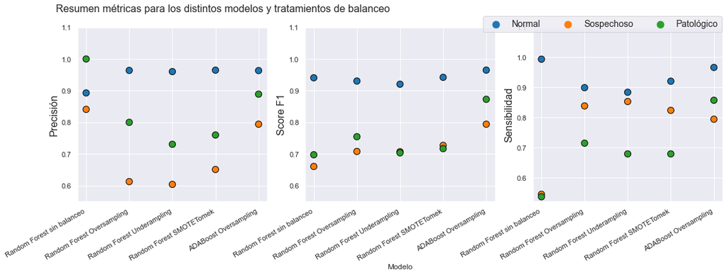

```python
#gráfico de Resumen otras métricas=p, s, f1
sns.set(palette=("tab10"))
f, axes = plt.subplots(1, 3,figsize=(18,5))
sns.scatterplot(data=result_p, x="Modelo", y="Precisión",ax=axes[0], hue="Clase",legend=False, s=100, edgecolor='black',
                linewidth=1)
sns.scatterplot(data=result_f1, x="Modelo", y="Score F1",ax=axes[1],hue="Clase", legend=False, s=100, edgecolor='black',
                linewidth=1)
sns.scatterplot(data=result_r, x="Modelo", y="Sensibilidad",ax=axes[2],hue="Clase", s=100, edgecolor='black',
                linewidth=1)
plt.setp(axes[0].get_xticklabels() + axes[1].get_xticklabels() + axes[2].get_xticklabels(), rotation=30, ha='right')
axes[0].set(ylim=(0.55, 1.1), xlabel=None)
axes[1].set(ylim=(0.55, 1.1))
axes[2].set(ylim=(0.52, 1.1), xlabel=None)
axes[0].set_ylabel('Precisión', fontsize = 16.0)
axes[1].set_ylabel('Score F1', fontsize = 16.0)
axes[2].set_ylabel('Sensibilidad', fontsize = 16.0)
plt.suptitle('Resumen métricas para los distintos modelos y tratamientos de balanceo', fontsize=16, horizontalalignment='right')
plt.legend(loc='upper right', ncol=3, bbox_to_anchor=(1.02, 1.09), fontsize=14, markerscale=1.8)
plt.savefig("Resumen métricas.jpg", bbox_inches='tight')
plt.show()
```

## Conclusión

### Prueba de armar dos clases: Normal vs. No Normal

```python
#Combino clases minoritarias y Llamo sospechoso y patologico como 2.0
drest = ds_sin_dup.replace(to_replace={'fetal_health': 3.0}, value=2.0)
```

```python
np.sum(drest['fetal_health'] == 1.0)
```

```
1646
```

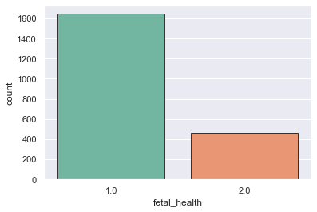

```python
#Gráfico de barras indicando cantidad total de cada clase.
sns.set(palette="Set2")
g=sns.countplot(x="fetal_health", data=drest, edgecolor=".2")
```

```python
#División de las columnas del data set en target (y=fetal_health) y predictoras (x)
y = drest.fetal_health
x = drest.drop('fetal_health', axis =1)
```

```python
#Separo en 80% train y 20% test set
from sklearn.model_selection import train_test_split
X_train_rest, X_test_rest, y_train_rest, y_test_rest = train_test_split(x, y, test_size=0.2, random_state=1)
```

```python
#Random Forest en el nuevo dataset
#Definicion de Hyperparámetros
param_grid = {'n_estimators': [60, 100, 120, 150],
    'max_features': ['auto'],
    'max_depth' : [2,3,4],
    'criterion' :['gini']}

model_rest = RandomForestClassifier(random_state=1)

#Utilizamos la grilla definida anteriormente
cv=StratifiedKFold(n_splits=5)
model_rest_GSCV = GridSearchCV(estimator=model_rest, param_grid=param_grid, cv=cv)

model_rest_GSCV.fit(X_train_rest,y_train_rest)
```

```
GridSearchCV(cv=StratifiedKFold(n_splits=5, random_state=None, shuffle=False),
             estimator=RandomForestClassifier(random_state=1),
             param_grid={'criterion': ['gini'], 'max_depth': [2, 3, 4],
                         'max_features': ['auto'],
                         'n_estimators': [60, 100, 120, 150]})
```

```python
model_rest_GSCV.best_params_
```

```
{'criterion': 'gini',
 'max_depth': 4,
 'max_features': 'auto',
 'n_estimators': 60}
```

```python
#Corro el modelo con los parámetros selecionados
model_best_rest=RandomForestClassifier(random_state=1, max_features='auto', n_estimators= 60, max_depth=4, criterion='gini')
```

```python
#Aplico los valores del Dataset que quiero analizar
model_best_rest.fit(X_train_rest,y_train_rest)

pred_rest = model_best_rest.predict(X_test_rest)
pred_rest
from sklearn import metrics
print("Accuracy:",metrics.accuracy_score(y_test_rest, pred_rest))
```

```
Accuracy: 0.9054373522458629
```

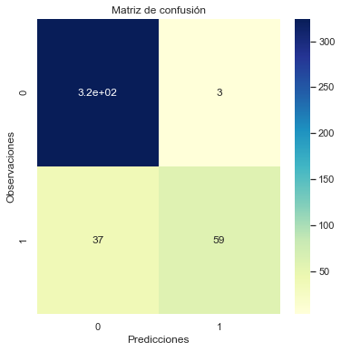

```
              precision    recall  f1-score   support

         1.0       0.90      0.99      0.94       327
         2.0       0.95      0.61      0.75        96

    accuracy                           0.91       423
   macro avg       0.92      0.80      0.84       423
weighted avg       0.91      0.91      0.90       423
```

```python
#Armamos la matriz de confusión
from sklearn.metrics import confusion_matrix
from sklearn.metrics import classification_report
def mostrar_resultados(y_test_rest, pred_rest):
    conf_matrix2 = confusion_matrix(y_test_rest, pred_rest)
    plt.figure(figsize=(6, 6))
    cm2=sns.heatmap(conf_matrix2, cmap="YlGnBu", annot=True);
    plt.title("Matriz de confusión")
    plt.ylabel('Observaciones')
    plt.xlabel('Predicciones')
    plt.savefig("Matriz 2.jpg", bbox_inches='tight')
    plt.show()

    print (classification_report(y_test_rest, pred_rest))

mostrar_resultados(y_test_rest, pred_rest)
```

La sensibilidad de 2.0, que serían los no normales es baja

Continuar con la opción de hacer AdaBoost sobre este nuevo dataset.